# 140.654 Lab 3

Erjia Cui, Jingning Zhang and Elizabeth Colantuoni

### Objectives

In this lab session, we will: 1. review the predictions of logistic regression; 2. evaluate the classifier performance using ROC curve.

```r
library(ggplot2)
library(dplyr)
library("pROC")
load('./../nmes.rdata')
data <- nmes
data[data=='.'] <- NA
data$bigexp=ifelse(data$totalexp>1000,1,0)
data$agem65=data$lastage-65
data$age_sp65 <- ifelse(data$lastage-65>=0,data$lastage-65,0)
data$marital <- as.factor(data$marital)
data$educate <- as.factor(data$educate)
data$povstalb <- as.factor(data$povstalb)
data$beltuse <- as.factor(data$beltuse)

dat <- data[,c('bigexp','lc5' ,'chd5','male','agem65','age_sp65','marital','educate','povstalb','beltuse')]
dat <- dat[complete.cases(dat),]
```

### 1. Introduction

Predictions from logistic regression or other models for binary responses can be used to classify subjects. The basic idea is to build a prediction model from “training” data that comprises binary response (or more generally categorical) Y and predictor variables X. For today’s lab, we focus on binary response Y (coded as 0,1). For the output of a prediction model, we could obtain predicted probability ($\hat{p_i},i=1,2,..,n$) for each person. Note $\hat{p_i}$ is estimated value of $Pr(Y_i = 1 | X) = E(Y_i|X)$.

Suppose we would like to use the following criteria to classify a new person($X_i$) (usually from “testing” dataset): $\forall c \in (0,1)$ (c is a given threshold), we create a dichotomous “prediction”, $d_i(c)$.
$$d_i(c)=\left\{
\begin{array}{ll}
1, if \hat{p_i} >c\\
0, if \hat{p_i} \leq c
\end{array}
\right.$$

After classifying each person, we can ask how well the classification system works using two measures of accuracy: sensitivity and specificity.

- Sensitivity(c) = $Pr(d(c)=1|Y=1)$: true-positive rate
- Specificity(c) = $Pr(d(c)=0|Y=0)$: true-negative rate

The goal is to find a set of predictor variables and model that have sensitivity and specificity values close to 1. The receiving operating characteristic (ROC) is a measure of classifier performance.

### 2. ROC

To illustrate, we use the National Medical Expenditure Survey (NMES) study data. We want to identify persons who are likely to spend more than $1,000 on medical services (i.e.bigexp) in a year, using their age, gender and whether they have a major smoking caused disease. We will distinguish lung cancer/COPD from coronary heart disease and stroke in the set of predictors. We can also use their poverty level, education and whether they regularly use a seat belt as a proxy for adversity to risk.

**Model 1**

```r
nrow(dat)
```

```
## [1] 12302
```

```r
fit <- glm(bigexp ~ lc5 + chd5 + male + agem65 + age_sp65 + marital + educate + povstalb + beltuse, family = 'binomial',data = dat)
summary(fit)
```

```
##
## Call:
## glm(formula = bigexp ~ lc5 + chd5 + male + agem65 + age_sp65 +
##     marital + educate + povstalb + beltuse, family = "binomial",
##     data = dat)
##
## Deviance Residuals:
##     Min       1Q   Median       3Q      Max
## -2.1113  -0.9075  -0.7358   1.2672   2.0161
##
## Coefficients:
##              Estimate Std. Error z value Pr(>|z|)
## (Intercept) -0.325921   0.106815  -3.051  0.00228 **
## lc5          1.533585   0.149942  10.228  < 2e-16 ***
## chd5         1.640347   0.072847  22.518  < 2e-16 ***
## male        -0.248982   0.042560  -5.850 4.91e-09 ***
## agem65       0.031731   0.002826  11.229  < 2e-16 ***
## age_sp65    -0.008399   0.005928  -1.417  0.15655
## marital2     0.011978   0.060141   0.199  0.84214
## marital3     0.239451   0.071775   3.336  0.00085 ***
## marital4     0.334113   0.124795   2.677  0.00742 **
## marital5    -0.068735   0.095942  -0.716  0.47373
## educate2     0.126186   0.075085   1.681  0.09285 .
## educate3    -0.122999   0.063450  -1.939  0.05256 .
## educate4    -0.314916   0.075422  -4.175 2.97e-05 ***
## povstalb2   -0.075931   0.103462  -0.734  0.46301
## povstalb3   -0.235158   0.079559  -2.956  0.00312 **
## povstalb4   -0.170698   0.072131  -2.366  0.01796 *
## povstalb5   -0.048023   0.074438  -0.645  0.51884
## beltuse2     0.055029   0.061501   0.895  0.37091
## beltuse3     0.080299   0.050254   1.598  0.11007
## ---
## Signif. codes:  0 '***' 0.001 '**' 0.01 '*' 0.05 '.' 0.1 ' ' 1
##
## (Dispersion parameter for binomial family taken to be 1)
##
##     Null deviance: 16194  on 12301  degrees of freedom
## Residual deviance: 14895  on 12283  degrees of freedom
## AIC: 14933
##
## Number of Fisher Scoring iterations: 4
```

Suppose we set the threshold c = 0.5, then:

```r
c <- 0.5 ## threshold
pred <- predict(fit, newdata = dat, type = 'response')
roc.5 <- data.frame(pred = ifelse(pred>c,1,0), truth = dat$bigexp)
table(pred = roc.5$pred, truth = roc.5$truth)
```

```
##     truth
## pred    0    1
##    0 7319 3379
##    1  449 1155
```

- Sensitivity = $\frac{1155}{1155 + 3379}$ = 0.25
- Specificity = $\frac{7319}{7319 + 449}$ = 0.94

**Tradeoff between Sensitivity and Specificity**

If we decrease the threshold, c = 0.25, the sensitivity improves but specificity decreases:

```r
c <- 0.25
pred <- predict(fit, newdata = dat, type = 'response')
roc.25 <- data.frame(pred = ifelse(pred>c,1,0), truth = dat$bigexp)
table(pred = roc.25$pred, truth = roc.25$truth)
```

```
##     truth
## pred    0    1
##    0 2007  525
##    1 5761 4009
```

- Sensitivity = $\frac{4009}{4009 + 525}$ = 0.88
- Specificity = $\frac{2007}{2007 + 5761}$ = 0.26

Rather than trying a couple of threshold values, we can calculate the whole functions sens(c) and spec(c) for all c in (0,1) and plot them against c.

**ROC plot and AUC estimation**

AUC: area under the curve

```r
ROC_fit <- roc(dat$bigexp, pred)
```

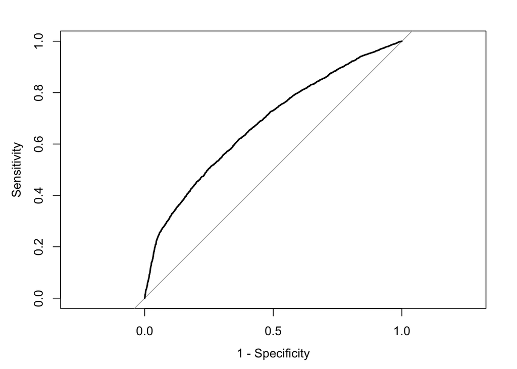

```r
plot(ROC_fit, legacy.axes = TRUE)
```

```r
# AUC
ROC_fit$auc
```

```
## Area under the curve: 0.6787
```

### 3. Cross-validated ROC curves (10 fold)

When evaluating models, we often want to assess how well it performs in predicting the response variable on different subsets of the data. One technique for doing this is k-fold cross-validation, which partitions the data into k equally sized folds and evaluates the performance/accuracy on hold-out (testing) dataset. It is a method to obtain less biased estimates of prediction error for a new set of Ys at the same Xs.

First we begin by generating group labels.

```r
# generate group labels
set.seed(123)
id_rand <- runif(nrow(dat))
n_fold <- 10
cv_group <- ntile(id_rand, n_fold)  # ntile(): a rough rank, which breaks the input vector into n buckets.
table(cv_group)
```

```
## cv_group
##    1    2    3    4    5    6    7    8    9   10
## 1231 1231 1230 1230 1230 1230 1230 1230 1230 1230
```

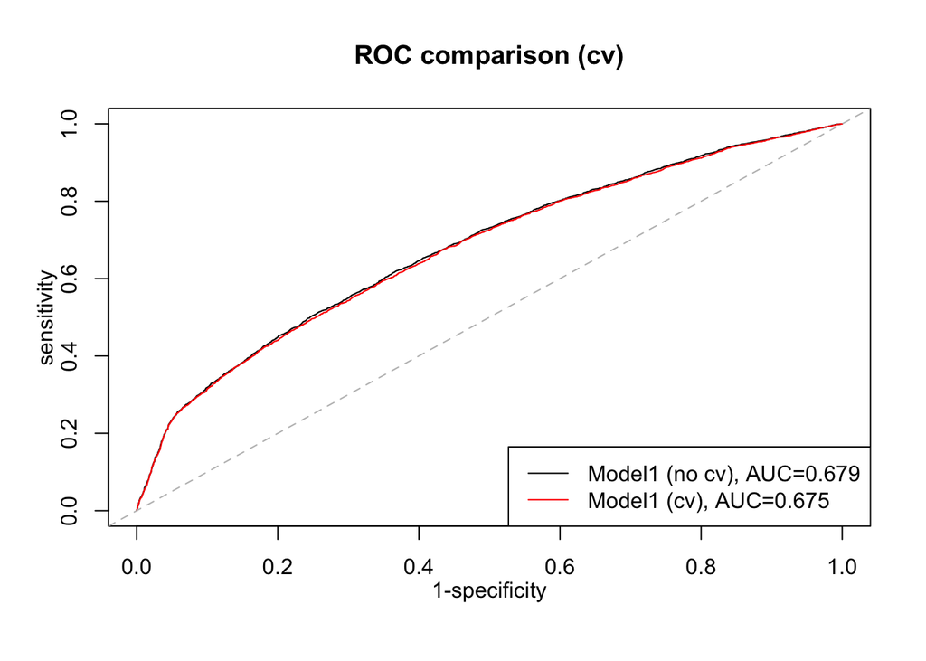

```r
# initialization
OutTrue <- dat$bigexp
X <- dat[,c('lc5' ,'chd5','male','agem65','age_sp65','marital','educate','povstalb','beltuse')]
cv_results <- array(0, c(0, 2))
colnames(cv_results) <- c("Truth", "Prob")

# begin cv
for (i in 1:n_fold) {
    # allocate people to the test and training sets
    data_train <- data.frame(X[cv_group != i, ], outcome = OutTrue[cv_group != i])
    data_test <- data.frame(X[cv_group == i, ], outcome = OutTrue[cv_group == i])

    fit_cv <- glm(outcome ~ lc5 + chd5 + male + agem65 + age_sp65 + marital + educate + povstalb + beltuse,family = 'binomial',data = data_train) # model 1

    # predict OutTrue on test set (those in cv_group==i)
    cv_results <- rbind(cv_results, data.frame(Truth = data_test$outcome,
        Prob = predict(fit_cv, data_test, type = "response")))
}


ROC_all_cv <- roc(cv_results$Truth, cv_results$Prob)
ROC_all <- roc(OutTrue, pred) # model1

plot(1 - ROC_all$specificities, ROC_all$sensitivities, xlim = c(0,
    1), ylim = c(0, 1), xlab = "", ylab = "", pch = 16, col = "black",
    cex = 0.8, type = "l", main = "ROC comparison (cv)")
points(1 - ROC_all_cv$specificities, ROC_all_cv$sensitivities,
    pch = 16, col = "red", cex = 0.8, type = "l")
abline(c(0, 1), col = "grey", lty = 2)
title(xlab = "1-specificity", line = 1.9)
title(ylab = "sensitivity", line = 1.9)
legend("bottomright", legend = c(paste0("Model1 (no cv), AUC=", format(ROC_all$auc,
    digits = 3)), paste0("Model1 (cv), AUC=", format(ROC_all_cv$auc,
    digits = 3))), lty = 1, col = c("black", "red"))
```

### In-class exercise

**Use cross-validated approach, for the following model (with interaction terms):**

In addition to Model 1, add 3 two-way interaction terms: lc5-male, chd5-male, age_sp65-marital

- Draw the ROC curve and report the AUC estimation
- Compare its performance against Model 1